# Final Project Kaggle Competition

Shusei Yokoi

6/3/2021

# Overview

Ask a home buyer to describe their dream house, and they probably won’t begin with the height of the basement ceiling or the proximity to an east-west railroad. But this playground competition’s dataset proves that much more influences price negotiations than the number of bedrooms or a white-picket fence.  
With 79 explanatory variables describing (almost) every aspect of residential homes in Ames, Iowa, this competition challenges you to predict the final price of each home.

Submissions are evaluated on Root-Mean-Squared-Error (RMSE) between the logarithm of the predicted value and the logarithm of the observed sales price. (Taking logs means that errors in predicting expensive houses and cheap houses will affect the result equally.)

With 79 explanatory variables, there are many missing data. Such as Alley, PoolQC, Fence, and MiscFeature contains 90% NA value. If the majority of explanatory variables are NA values, I simply removed from the training data set. Other than that, I simply replaced them with the most common class; for categorical and a median; for numeric variable. In the test data set given, there are a lot of NA values and new categories that does not appears in training data set. Therefore, Most of the explanatory variables are not helpful.

# Variable selection (Numeric)

I pick variables with correlation of more than |0.3|.

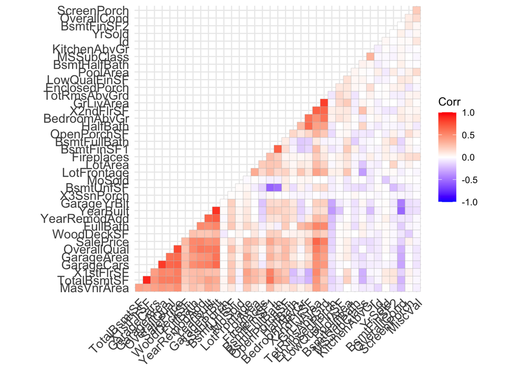

```r
house_num<- dplyr::select_if(house, is.numeric)

r <- cor(house_num, use="complete.obs") %>%
  data.frame()

ggcorrplot::ggcorrplot(r, hc.order = TRUE, type = "lower")
```

```r
variable = colnames(r[r$SalePrice > abs(0.3)])
variable = head(variable, -1)
```

Here are the numeric variables that was +|0.3| correlation to Sales Price OverallQual, YearBuilt, YearRemodAdd, MasVnrArea, BsmtFinSF1, TotalBsmtSF, X1stFlrSF, GrLivArea, FullBath, TotRmsAbvGrd, GarageYrBlt, GarageCars, GarageArea

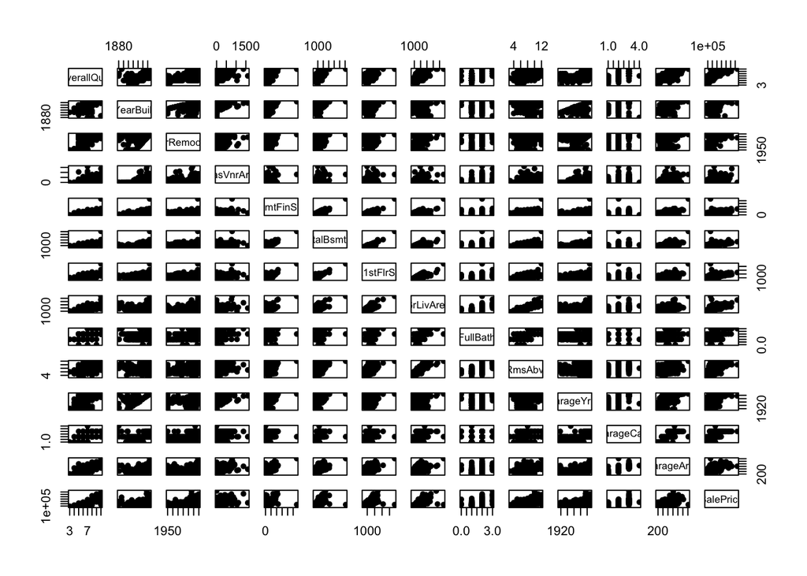

```r
pairs(train[c(variable, "SalePrice")], pch = 16)
```